# Testing affect regulation via computational modeling of real-time alcohol choices in daily life: Drift Rate

2026-04-06

# 1 About This Report

This report presents results for **Drift Rate** (drift) across all four focal predictors: stress (binary), stress (state), negative affect (state), and positive affect (state).

For each predictor, the report is organized as follows:

- **Dimensionality reduction:** PCA and UMAP component composition tables, showing which raw variables load most strongly onto each component.
- **GLMM results (raw features):** Summary of results from GLMM model with raw variables.
- **Random forest results (raw features):** Summary of results from random forest model with raw variables.
- **Model comparison:** RMSE comparison table across all methods (GLMM, random forest, decision tree) and feature sets (raw, PCA, UMAP).

# 2 Stress Binary (stress_binary)

## 2.1 Dimensionality Reduction

- **PCA components (80% variance, max 5):** 5
- **UMAP components (matching PCA):** 5

### 2.1.1 PCA Component Composition (top 5 correlated variables)

**PC_1**

| Variable | Correlation |
| --- | --- |
| alc_exp_energeticYes | -0.576 |
| alc_exp_better_moodYes | -0.557 |
| alc_exp_sociableYes | -0.547 |
| alc_exp_buzzYes | -0.502 |
| alc_craving | -0.487 |

**PC_2**

| Variable | Correlation |
| --- | --- |
| alc_exp_injuryYes | -0.596 |
| alc_exp_be_rudeYes | -0.594 |
| alc_exp_embarrassedYes | -0.579 |
| alc_exp_nauseous_vomitYes | -0.491 |
| alc_exp_hangoverYes | -0.468 |

**PC_3**

| Variable | Correlation |
| --- | --- |
| locationschool_work | 0.591 |
| alc_today | -0.578 |
| alc_cuenone | 0.568 |
| time_of_dayevening | -0.476 |
| locationhome | -0.458 |

**PC_4**

| Variable | Correlation |
| --- | --- |
| soft_yday | 0.699 |
| soft_today | 0.650 |
| soft_intend | 0.634 |
| soft_craving | 0.489 |
| alc_exp_embarrassedYes | -0.388 |

**PC_5**

| Variable | Correlation |
| --- | --- |
| locationhome | -0.632 |
| social_context_aloneYes | -0.560 |
| social_context_friend_roommateYes | 0.500 |
| social_context_strangerYes | 0.417 |
| locationsomeone_elses_home | 0.372 |

### 2.1.2 UMAP Component Composition (top 5 correlated variables)

**UMAP_1**

| Variable | Correlation |
| --- | --- |
| alc_exp_embarrassedYes | 0.271 |
| alc_exp_be_rudeYes | 0.267 |
| alc_yday | 0.242 |
| alc_intend | 0.227 |
| alc_craving | 0.226 |

**UMAP_2**

| Variable | Correlation |
| --- | --- |
| alc_yday | -0.283 |
| alc_exp_embarrassedYes | 0.191 |
| alc_exp_be_rudeYes | 0.187 |
| alc_mot_enhanceYes | -0.107 |
| responsibilityYes | -0.096 |

**UMAP_3**

| Variable | Correlation |
| --- | --- |
| alc_yday | -0.438 |
| alc_today | -0.426 |
| alc_cuenone | 0.186 |
| alc_intend | -0.174 |
| social_context_familyYes | -0.136 |

**UMAP_4**

| Variable | Correlation |
| --- | --- |
| soft_yday | 0.822 |
| soft_today | 0.716 |
| soft_intend | 0.589 |
| soft_craving | 0.314 |
| alc_exp_be_rudeYes | 0.172 |

**UMAP_5**

| Variable | Correlation |
| --- | --- |
| alc_exp_injuryYes | 0.511 |
| alc_exp_embarrassedYes | 0.378 |
| alc_exp_be_rudeYes | 0.376 |
| alc_exp_nauseous_vomitYes | 0.353 |
| alc_exp_energeticYes | 0.235 |

## 2.2 GLMM Results

### 2.2.1 Raw Features

- **Optimal lambda:** 10 (index 19 of 21)
- **CV RMSE:** 0.3114

**Non-zero coefficients** (focal predictor terms highlighted):

| Term | Estimate | Category |
| --- | --- | --- |
| (Intercept) | 0.3655 | Intercept |
| stress_binary | 0.0021 | Focal predictor |
| alc_exp_embarrassedYes | -0.0543 | Covariate main effect |
| alc_exp_injuryYes | -0.0539 | Covariate main effect |
| alc_exp_be_rudeYes | -0.0460 | Covariate main effect |
| alc_exp_nauseous_vomitYes | -0.0359 | Covariate main effect |
| alc_exp_hangoverYes | -0.0342 | Covariate main effect |
| alc_exp_relaxedYes | 0.0283 | Covariate main effect |
| alc_exp_better_moodYes | 0.0180 | Covariate main effect |
| social_context_strangerYes | 0.0178 | Covariate main effect |
| alc_cuenone | -0.0178 | Covariate main effect |
| locationother | 0.0158 | Covariate main effect |
| alc_cueindirectly_visible | -0.0131 | Covariate main effect |
| alc_mot_enhanceYes | 0.0120 | Covariate main effect |
| locationrestaurant_cafe | -0.0118 | Covariate main effect |
| alc_mot_copingYes | 0.0117 | Covariate main effect |
| social_context_familyYes | -0.0094 | Covariate main effect |
| social_context_coworker_classmateYes | 0.0087 | Covariate main effect |
| alc_exp_sociableYes | -0.0086 | Covariate main effect |
| alc_exp_buzzYes | 0.0086 | Covariate main effect |
| soft_intend | -0.0074 | Covariate main effect |
| alc_craving | 0.0067 | Covariate main effect |
| responsibilityYes | -0.0066 | Covariate main effect |
| time_of_dayevening | -0.0063 | Covariate main effect |
| soft_today | -0.0062 | Covariate main effect |
| alc_intend | 0.0062 | Covariate main effect |
| social_context_romantic_partnerYes | 0.0057 | Covariate main effect |
| bored_state | 0.0047 | Covariate main effect |
| soft_yday | -0.0043 | Covariate main effect |
| thirst_state | 0.0030 | Covariate main effect |

[output cut: 59 more lines]

- 9 coefficients penalized to zero.*

#### 2.2.1.1 Predicted vs. Observed

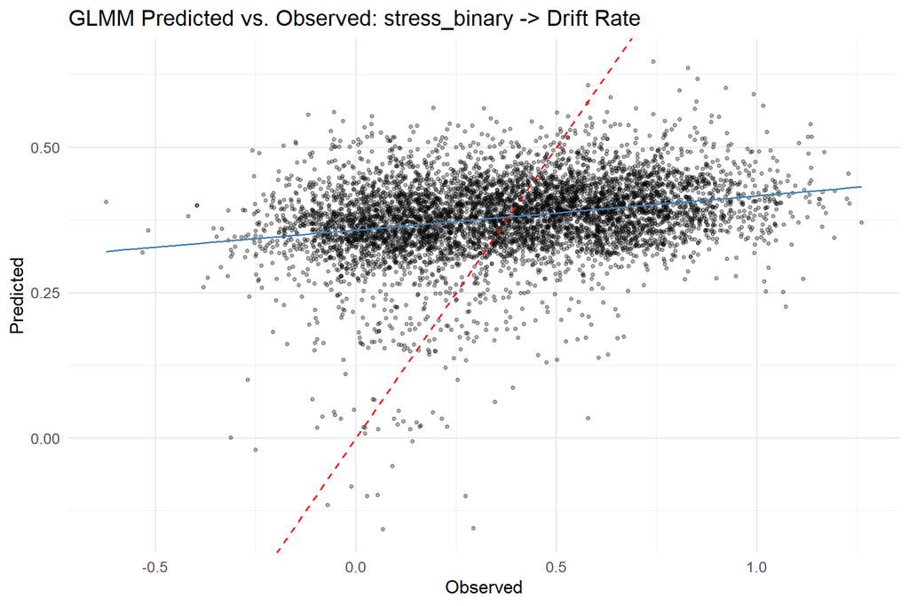

#### 2.2.1.2 Residual Diagnostics

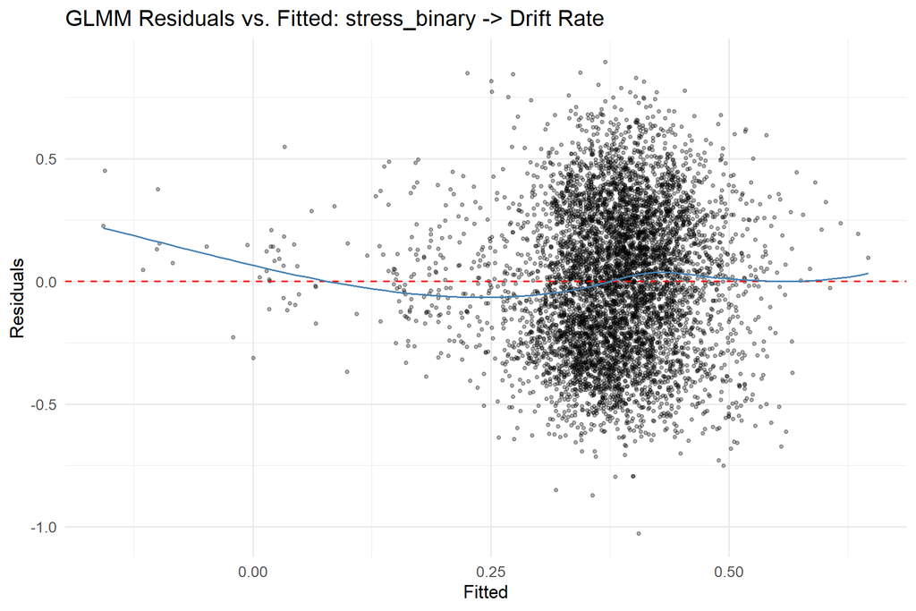

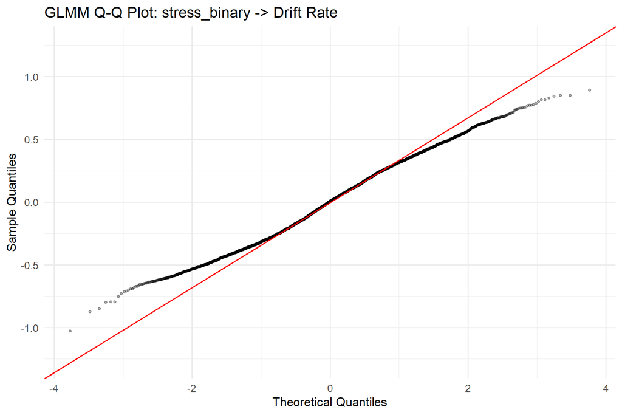

### 2.2.2 PCA Features

- **Optimal lambda:** 100 (index 1 of 21)
- **CV RMSE:** 0.3083

**Non-zero coefficients:**

| Term | Estimate |
| --- | --- |
| (Intercept) | 0.3803 |
| PC_2 | 0.0434 |
| PC_5 | -0.0069 |
| PC_5:stress_binary | 0.0059 |

- 8 coefficients penalized to zero.*

### 2.2.3 UMAP Features

- **Optimal lambda:** 95 (index 2 of 21)
- **CV RMSE:** 0.3083

**Non-zero coefficients:**

| Term | Estimate |
| --- | --- |
| (Intercept) | 0.3807 |
| UMAP_3 | -0.0074 |
| UMAP_4 | -0.0190 |
| UMAP_3:stress_binary | -0.0062 |
| UMAP_5:stress_binary | -0.0119 |

- 7 coefficients penalized to zero.*

## 2.3 Random Forest Results (Raw)

### 2.3.1 Tuning Summary

- **mtry:** 12
- **min.node.size:** 4
- **sample.fraction:** 0.833
- **CV RMSE:** 0.2558

### 2.3.2 Variable Importance (Permutation)

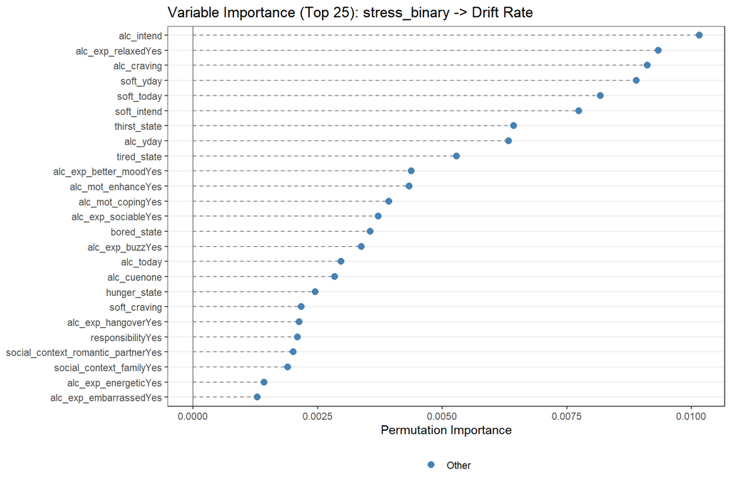

**Full importance ranking:**

| Variable | Importance |
| --- | --- |
| alc_intend | 0.010161 |
| alc_exp_relaxedYes | 0.009337 |
| alc_craving | 0.009113 |
| soft_yday | 0.008898 |
| soft_today | 0.008171 |
| soft_intend | 0.007741 |
| thirst_state | 0.006435 |
| alc_yday | 0.006330 |
| tired_state | 0.005284 |
| alc_exp_better_moodYes | 0.004381 |
| alc_mot_enhanceYes | 0.004337 |
| alc_mot_copingYes | 0.003926 |
| alc_exp_sociableYes | 0.003715 |
| bored_state | 0.003552 |
| alc_exp_buzzYes | 0.003381 |
| alc_today | 0.002967 |
| alc_cuenone | 0.002841 |
| hunger_state | 0.002453 |
| soft_craving | 0.002170 |
| alc_exp_hangoverYes | 0.002133 |
| responsibilityYes | 0.002100 |
| social_context_romantic_partnerYes | 0.002012 |
| social_context_familyYes | 0.001901 |
| alc_exp_energeticYes | 0.001422 |
| alc_exp_embarrassedYes | 0.001291 |
| social_context_aloneYes | 0.001196 |
| time_of_dayevening | 0.000962 |
| alc_exp_be_rudeYes | 0.000905 |
| locationhome | 0.000868 |
| alc_mot_socialYes | 0.000741 |
| stress_binary | 0.000723 |
| locationschool_work | 0.000549 |
| alc_exp_nauseous_vomitYes | 0.000437 |
| locationother | 0.000399 |
| alc_exp_injuryYes | 0.000298 |
| alc_cueindirectly_visible | 0.000269 |
| social_context_friend_roommateYes | 0.000230 |
| social_context_coworker_classmateYes | 0.000228 |
| social_context_strangerYes | 0.000195 |
| locationoutdoors | 0.000063 |
| locationsomeone_elses_home | 0.000027 |
| locationrestaurant_cafe | 0.000020 |
| social_context_otherYes | 0.000014 |
| day_of_weekSun | 0.000005 |
| day_of_weekMon | -0.000033 |
| day_of_weekSat | -0.000076 |
| day_of_weekTue | -0.000157 |
| day_of_weekWed | -0.000191 |
| day_of_weekThu | -0.000219 |

### 2.3.3 Partial Dependence Plots

PDP for the focal predictor and the top 5 most important non-interaction covariates.

#### 2.3.3.1 Focal Predictor: stress_binary

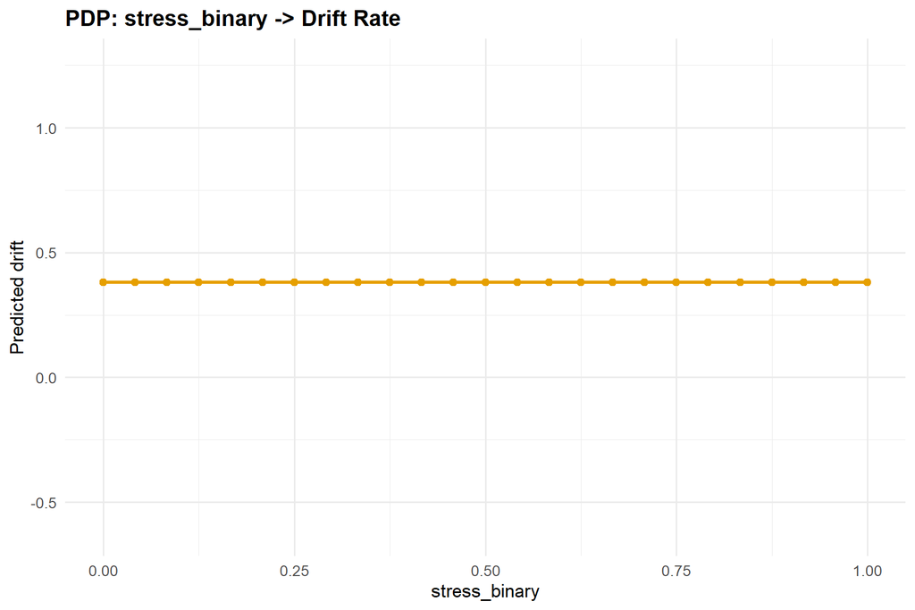

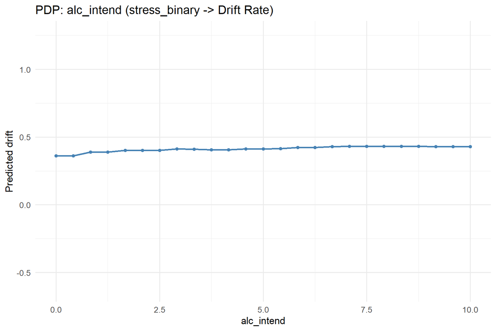

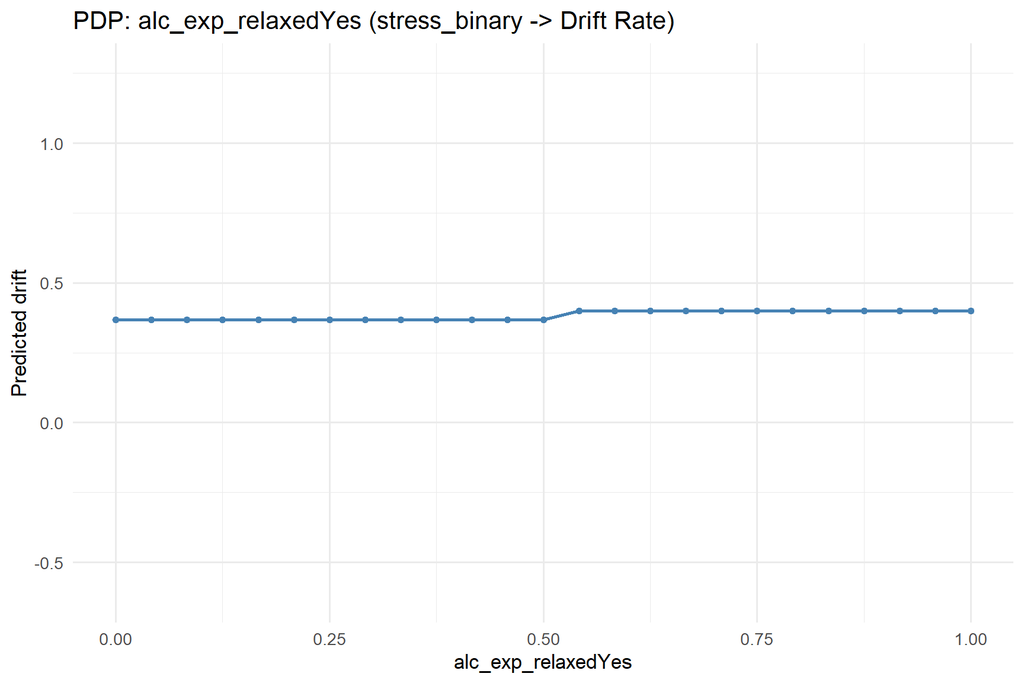

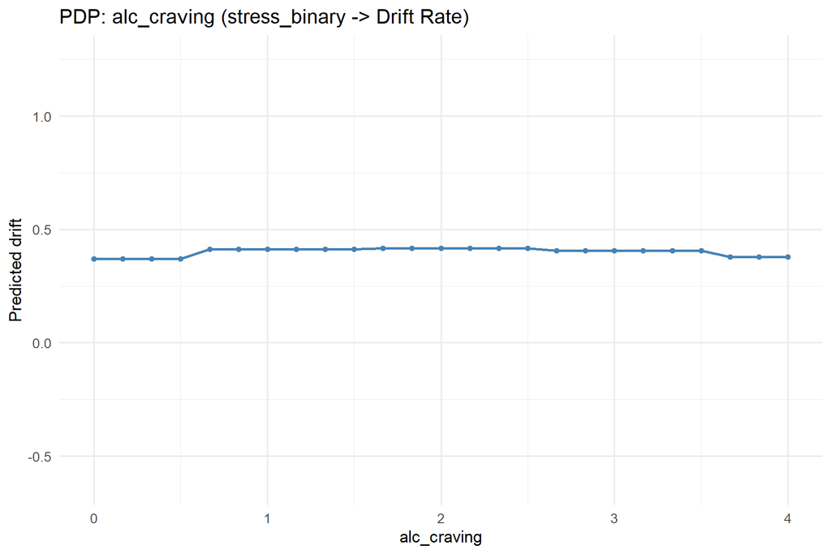

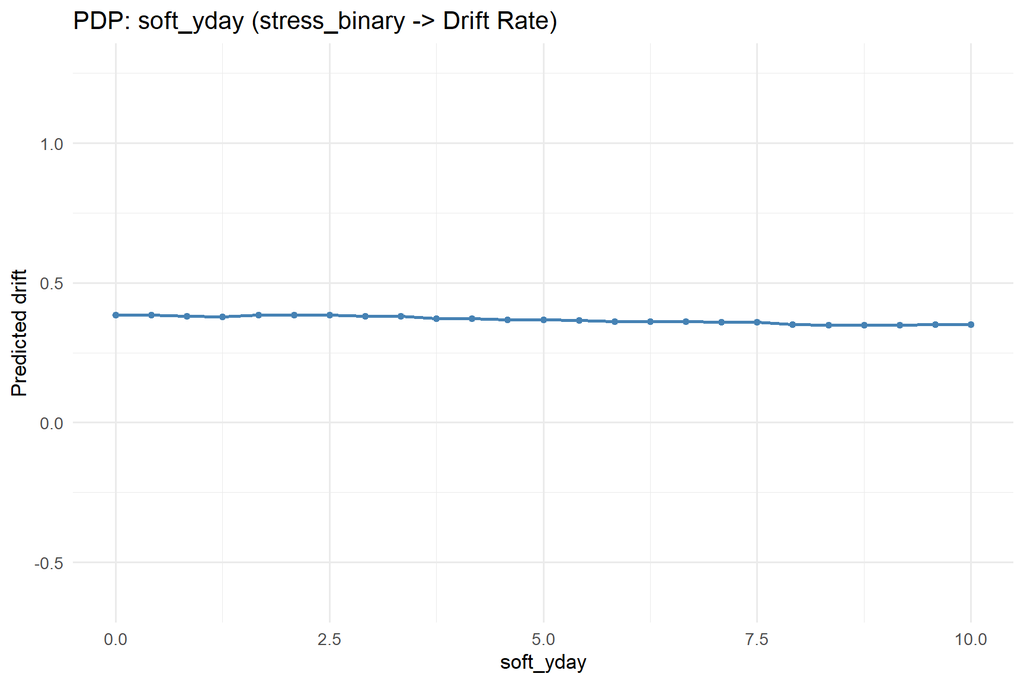

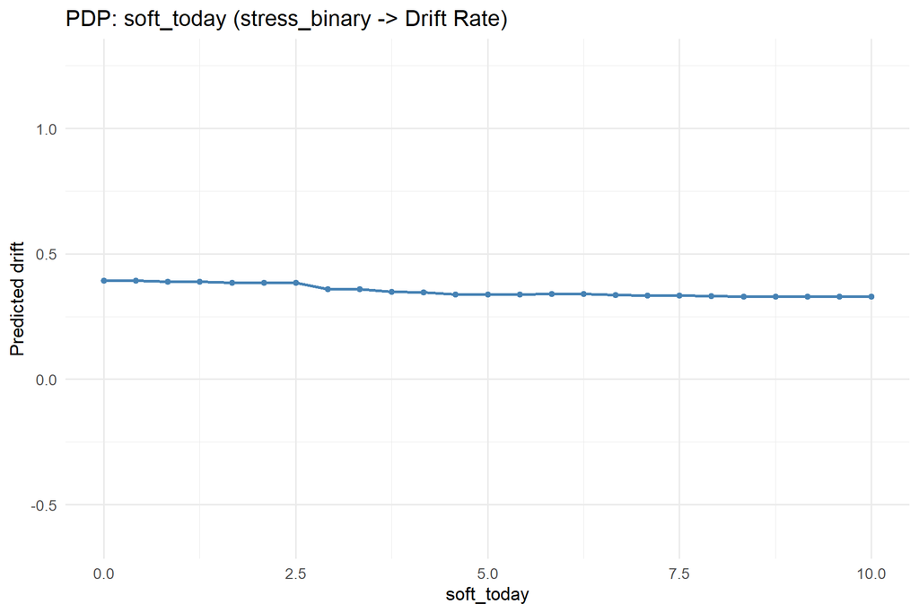

### 2.3.4 Predicted vs. Observed

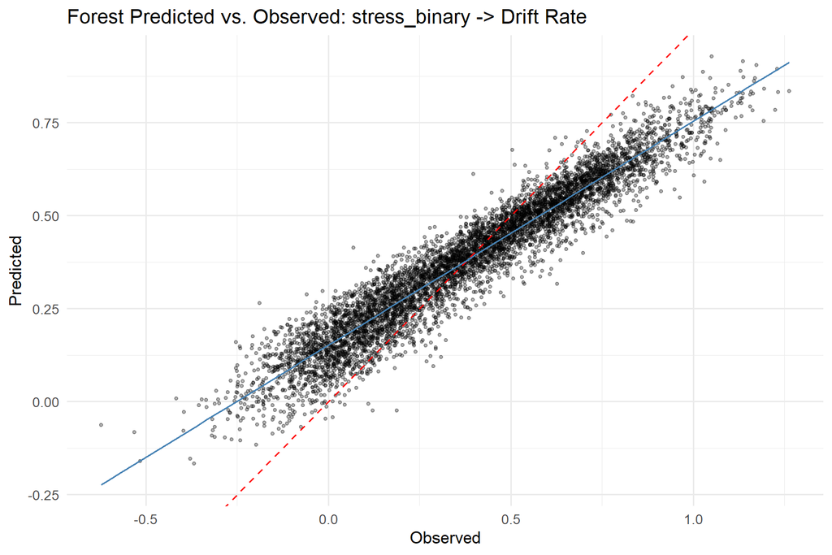

## 2.4 Model Comparison

### 2.4.1 RMSE Comparison (all methods and feature sets)

| Method | Raw | PCA | UMAP |
| --- | --- | --- | --- |
| glmm | 0.3114 | 0.3083 | 0.3083 |
| forest | 0.2558 | 0.2866 | 0.2740 |
| tree | 0.3019 | 0.3026 | 0.3043 |

# 3 Stress State (stress_state)

## 3.1 Dimensionality Reduction

- **PCA components (80% variance, max 5):** 5
- **UMAP components (matching PCA):** 5

### 3.1.1 PCA Component Composition (top 5 correlated variables)

**PC_1**

| Variable | Correlation |
| --- | --- |
| alc_exp_energeticYes | -0.576 |
| alc_exp_better_moodYes | -0.557 |
| alc_exp_sociableYes | -0.547 |
| alc_exp_buzzYes | -0.502 |
| alc_craving | -0.487 |

**PC_2**

| Variable | Correlation |
| --- | --- |
| alc_exp_injuryYes | -0.595 |
| alc_exp_be_rudeYes | -0.593 |
| alc_exp_embarrassedYes | -0.578 |
| alc_exp_nauseous_vomitYes | -0.491 |
| alc_exp_hangoverYes | -0.467 |

**PC_3**

| Variable | Correlation |
| --- | --- |
| locationschool_work | 0.591 |
| alc_today | -0.578 |
| alc_cuenone | 0.569 |
| time_of_dayevening | -0.476 |
| locationhome | -0.459 |

**PC_4**

| Variable | Correlation |
| --- | --- |
| soft_yday | 0.697 |
| soft_today | 0.649 |
| soft_intend | 0.634 |
| soft_craving | 0.489 |
| alc_exp_embarrassedYes | -0.389 |

**PC_5**

| Variable | Correlation |
| --- | --- |
| locationhome | -0.632 |
| social_context_aloneYes | -0.560 |
| social_context_friend_roommateYes | 0.501 |
| social_context_strangerYes | 0.418 |
| locationsomeone_elses_home | 0.372 |

### 3.1.2 UMAP Component Composition (top 5 correlated variables)

**UMAP_1**

| Variable | Correlation |
| --- | --- |
| alc_yday | 0.448 |
| alc_intend | 0.307 |
| alc_craving | 0.199 |
| alc_exp_embarrassedYes | 0.188 |
| alc_exp_be_rudeYes | 0.186 |

**UMAP_2**

| Variable | Correlation |
| --- | --- |
| alc_exp_embarrassedYes | 0.270 |
| alc_exp_be_rudeYes | 0.265 |
| alc_yday | -0.164 |
| responsibilityYes | -0.126 |
| thirst_state | -0.120 |

**UMAP_3**

| Variable | Correlation |
| --- | --- |
| alc_yday | 0.464 |
| alc_today | 0.442 |
| alc_cuenone | -0.191 |
| alc_intend | 0.155 |
| time_of_dayevening | 0.148 |

**UMAP_4**

| Variable | Correlation |
| --- | --- |
| soft_yday | -0.833 |
| soft_today | -0.757 |
| soft_intend | -0.593 |
| soft_craving | -0.330 |
| alc_exp_be_rudeYes | -0.166 |

**UMAP_5**

| Variable | Correlation |
| --- | --- |
| alc_exp_injuryYes | -0.502 |
| alc_exp_embarrassedYes | -0.370 |
| alc_exp_be_rudeYes | -0.368 |
| alc_exp_nauseous_vomitYes | -0.343 |
| alc_exp_energeticYes | -0.243 |

## 3.2 GLMM Results

### 3.2.1 Raw Features

- **Optimal lambda:** 30 (index 15 of 21)
- **CV RMSE:** 0.3079

**Non-zero coefficients** (focal predictor terms highlighted):

| Term | Estimate | Category |
| --- | --- | --- |
| (Intercept) | 0.3346 | Intercept |
| stress_state | 0.0052 | Focal predictor |
| alc_exp_injuryYes | -0.0323 | Covariate main effect |
| alc_exp_embarrassedYes | -0.0311 | Covariate main effect |
| alc_exp_be_rudeYes | -0.0267 | Covariate main effect |
| alc_exp_nauseous_vomitYes | -0.0204 | Covariate main effect |
| alc_exp_hangoverYes | -0.0188 | Covariate main effect |
| alc_exp_relaxedYes | 0.0151 | Covariate main effect |
| alc_exp_better_moodYes | 0.0097 | Covariate main effect |
| alc_cuenone | -0.0083 | Covariate main effect |
| social_context_strangerYes | 0.0072 | Covariate main effect |
| locationother | 0.0062 | Covariate main effect |
| alc_mot_enhanceYes | 0.0061 | Covariate main effect |
| alc_mot_copingYes | 0.0057 | Covariate main effect |
| alc_cueindirectly_visible | -0.0045 | Covariate main effect |
| alc_exp_buzzYes | 0.0041 | Covariate main effect |
| soft_intend | -0.0039 | Covariate main effect |
| alc_craving | 0.0037 | Covariate main effect |
| soft_today | -0.0034 | Covariate main effect |
| alc_intend | 0.0034 | Covariate main effect |
| social_context_familyYes | -0.0032 | Covariate main effect |
| alc_exp_sociableYes | -0.0027 | Covariate main effect |
| soft_yday | -0.0025 | Covariate main effect |
| time_of_dayevening | -0.0024 | Covariate main effect |
| responsibilityYes | -0.0023 | Covariate main effect |
| social_context_coworker_classmateYes | 0.0019 | Covariate main effect |
| bored_state | 0.0018 | Covariate main effect |
| social_context_romantic_partnerYes | 0.0017 | Covariate main effect |
| thirst_state | 0.0012 | Covariate main effect |
| soft_craving | -0.0011 | Covariate main effect |
| alc_yday | 0.0009 | Covariate main effect |
| hunger_state | 0.0005 | Covariate main effect |
| tired_state | 0.0004 | Covariate main effect |
| alc_exp_embarrassedYes:stress_state | -0.0080 | Interaction with focal predictor |
| alc_exp_injuryYes:stress_state | -0.0078 | Interaction with focal predictor |
| social_context_strangerYes:stress_state | 0.0077 | Interaction with focal predictor |
| locationother:stress_state | 0.0067 | Interaction with focal predictor |
| alc_exp_relaxedYes:stress_state | 0.0066 | Interaction with focal predictor |
| alc_exp_be_rudeYes:stress_state | -0.0065 | Interaction with focal predictor |
| alc_exp_better_moodYes:stress_state | 0.0052 | Interaction with focal predictor |
| alc_exp_hangoverYes:stress_state | -0.0050 | Interaction with focal predictor |
| day_of_weekSat:stress_state | 0.0044 | Interaction with focal predictor |
| locationhome:stress_state | 0.0040 | Interaction with focal predictor |
| alc_exp_nauseous_vomitYes:stress_state | -0.0039 | Interaction with focal predictor |
| alc_mot_enhanceYes:stress_state | 0.0039 | Interaction with focal predictor |
| responsibilityYes:stress_state | 0.0038 | Interaction with focal predictor |
| alc_mot_copingYes:stress_state | 0.0037 | Interaction with focal predictor |
| alc_exp_buzzYes:stress_state | 0.0036 | Interaction with focal predictor |
| time_of_dayevening:stress_state | 0.0035 | Interaction with focal predictor |
| social_context_familyYes:stress_state | 0.0032 | Interaction with focal predictor |
| social_context_coworker_classmateYes:stress_state | 0.0030 | Interaction with focal predictor |
| alc_cuenone:stress_state | 0.0030 | Interaction with focal predictor |
| alc_mot_socialYes:stress_state | 0.0029 | Interaction with focal predictor |
| social_context_aloneYes:stress_state | 0.0028 | Interaction with focal predictor |
| day_of_weekThu:stress_state | 0.0026 | Interaction with focal predictor |
| social_context_friend_roommateYes:stress_state | 0.0022 | Interaction with focal predictor |
| day_of_weekTue:stress_state | 0.0019 | Interaction with focal predictor |
| day_of_weekMon:stress_state | 0.0017 | Interaction with focal predictor |
| social_context_romantic_partnerYes:stress_state | 0.0015 | Interaction with focal predictor |
| tired_state:stress_state | 0.0014 | Interaction with focal predictor |
| alc_intend:stress_state | 0.0013 | Interaction with focal predictor |
| thirst_state:stress_state | 0.0013 | Interaction with focal predictor |
| hunger_state:stress_state | 0.0013 | Interaction with focal predictor |
| bored_state:stress_state | 0.0012 | Interaction with focal predictor |
| alc_craving:stress_state | 0.0012 | Interaction with focal predictor |
| day_of_weekSun:stress_state | 0.0012 | Interaction with focal predictor |
| alc_yday:stress_state | 0.0009 | Interaction with focal predictor |
| locationsomeone_elses_home:stress_state | 0.0007 | Interaction with focal predictor |
| alc_today:stress_state | 0.0006 | Interaction with focal predictor |
| soft_intend:stress_state | -0.0002 | Interaction with focal predictor |
| locationoutdoors:stress_state | 0.0002 | Interaction with focal predictor |
| day_of_weekWed:stress_state | 0.0002 | Interaction with focal predictor |
| soft_today:stress_state | -0.0001 | Interaction with focal predictor |

- 25 coefficients penalized to zero.*

#### 3.2.1.1 Predicted vs. Observed

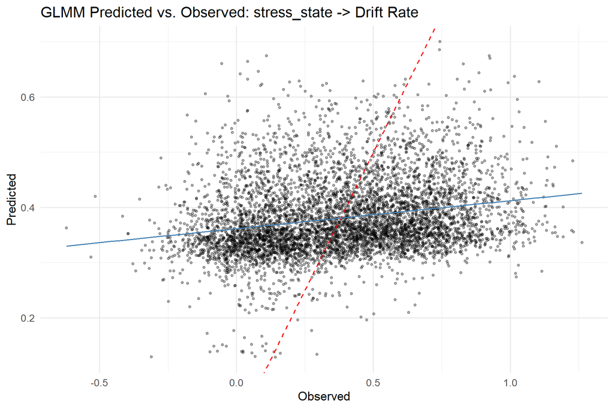

#### 3.2.1.2 Residual Diagnostics

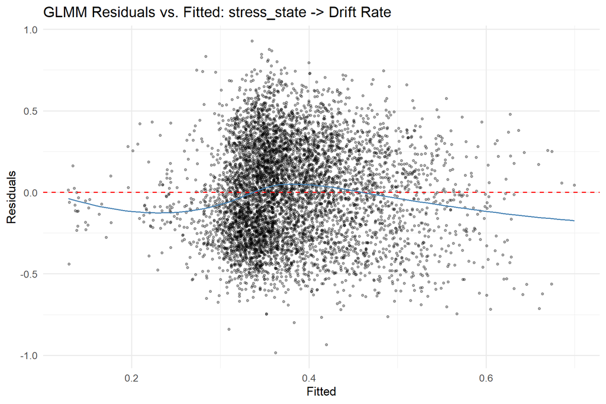

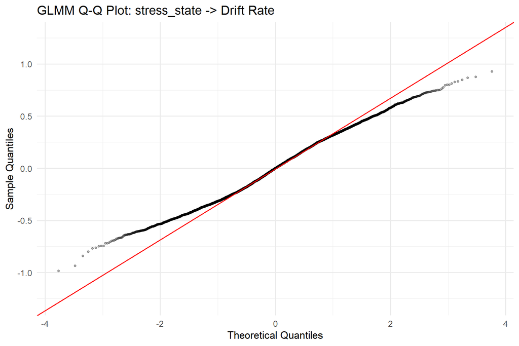

### 3.2.2 PCA Features

- **Optimal lambda:** 95 (index 2 of 21)
- **CV RMSE:** 0.3084

**Non-zero coefficients:**

| Term | Estimate |
| --- | --- |
| (Intercept) | 0.3660 |
| PC_2 | 0.0413 |
| stress_state | 0.0149 |
| PC_2:stress_state | 0.0039 |
| PC_5:stress_state | -0.0050 |

- 7 coefficients penalized to zero.*

### 3.2.3 UMAP Features

- **Optimal lambda:** 95 (index 2 of 21)
- **CV RMSE:** 0.305

**Non-zero coefficients:**

| Term | Estimate |
| --- | --- |
| (Intercept) | 0.3647 |
| UMAP_3 | 0.0129 |
| UMAP_4 | 0.0178 |
| stress_state | 0.0174 |
| UMAP_3:stress_state | -0.0001 |
| UMAP_4:stress_state | 0.0002 |
| UMAP_5:stress_state | 0.0068 |

- 5 coefficients penalized to zero.*

## 3.3 Random Forest Results (Raw)

### 3.3.1 Tuning Summary

- **mtry:** 14
- **min.node.size:** 6
- **sample.fraction:** 0.801
- **CV RMSE:** 0.256

### 3.3.2 Variable Importance (Permutation)

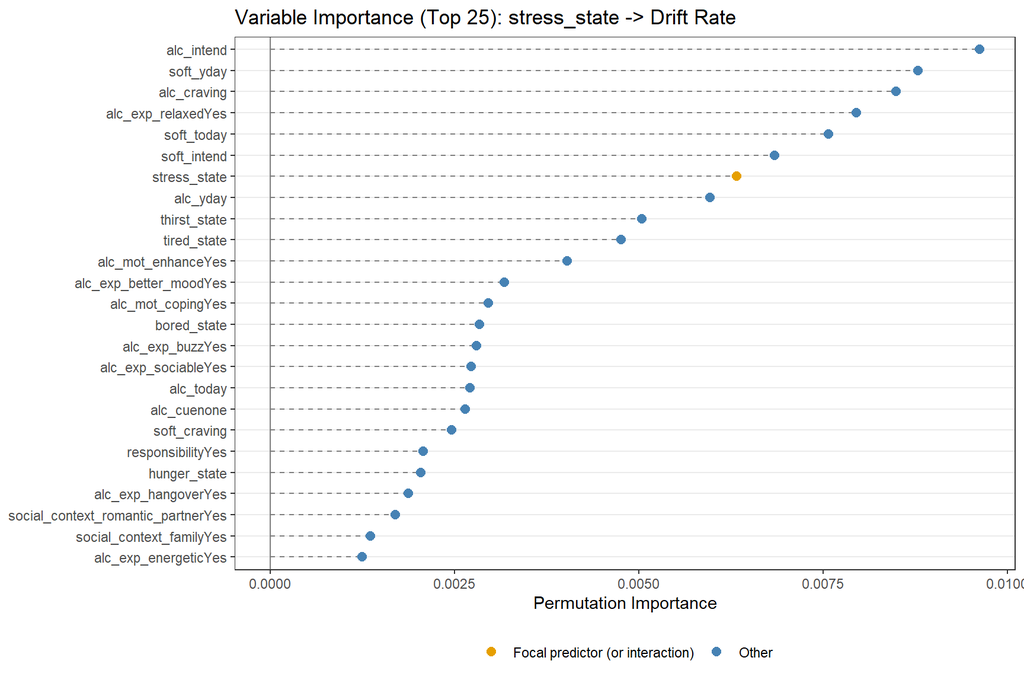

**Full importance ranking:**

| Variable | Importance |
| --- | --- |
| alc_intend | 0.009622 |
| soft_yday | 0.008783 |
| alc_craving | 0.008492 |
| alc_exp_relaxedYes | 0.007949 |
| soft_today | 0.007573 |
| soft_intend | 0.006843 |
| stress_state | 0.006330 |
| alc_yday | 0.005966 |
| thirst_state | 0.005043 |
| tired_state | 0.004761 |
| alc_mot_enhanceYes | 0.004023 |
| alc_exp_better_moodYes | 0.003172 |
| alc_mot_copingYes | 0.002958 |
| bored_state | 0.002836 |
| alc_exp_buzzYes | 0.002798 |
| alc_exp_sociableYes | 0.002720 |
| alc_today | 0.002706 |
| alc_cuenone | 0.002641 |
| soft_craving | 0.002460 |
| responsibilityYes | 0.002076 |
| hunger_state | 0.002042 |
| alc_exp_hangoverYes | 0.001870 |
| social_context_romantic_partnerYes | 0.001699 |
| social_context_familyYes | 0.001355 |
| alc_exp_energeticYes | 0.001247 |
| alc_exp_embarrassedYes | 0.001108 |
| time_of_dayevening | 0.001028 |
| social_context_aloneYes | 0.001005 |
| alc_exp_be_rudeYes | 0.000772 |
| locationhome | 0.000762 |
| alc_mot_socialYes | 0.000557 |
| locationschool_work | 0.000474 |
| alc_exp_nauseous_vomitYes | 0.000325 |
| locationother | 0.000290 |
| alc_exp_injuryYes | 0.000264 |
| alc_cueindirectly_visible | 0.000226 |
| social_context_coworker_classmateYes | 0.000188 |
| social_context_friend_roommateYes | 0.000154 |
| social_context_strangerYes | 0.000150 |
| locationsomeone_elses_home | 0.000062 |
| locationoutdoors | 0.000048 |
| day_of_weekSun | 0.000018 |
| social_context_otherYes | 0.000018 |
| locationrestaurant_cafe | 0.000007 |
| day_of_weekSat | 0.000003 |
| day_of_weekMon | -0.000104 |
| day_of_weekTue | -0.000156 |
| day_of_weekWed | -0.000161 |
| day_of_weekThu | -0.000185 |

### 3.3.3 Partial Dependence Plots

PDP for the focal predictor and the top 5 most important non-interaction covariates.

#### 3.3.3.1 Focal Predictor: stress_state

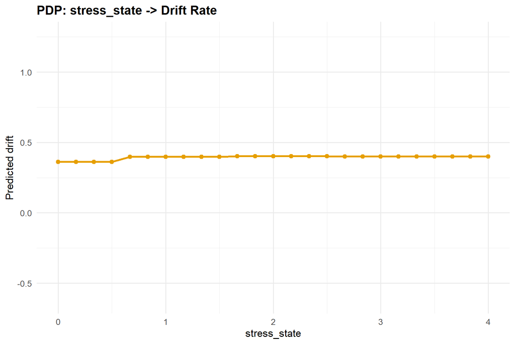

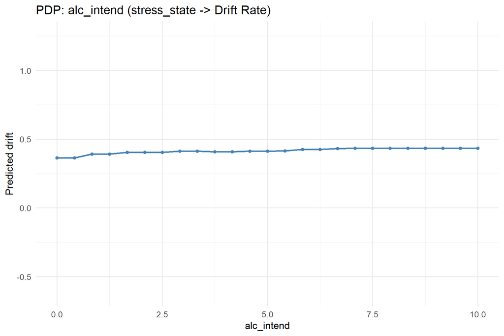

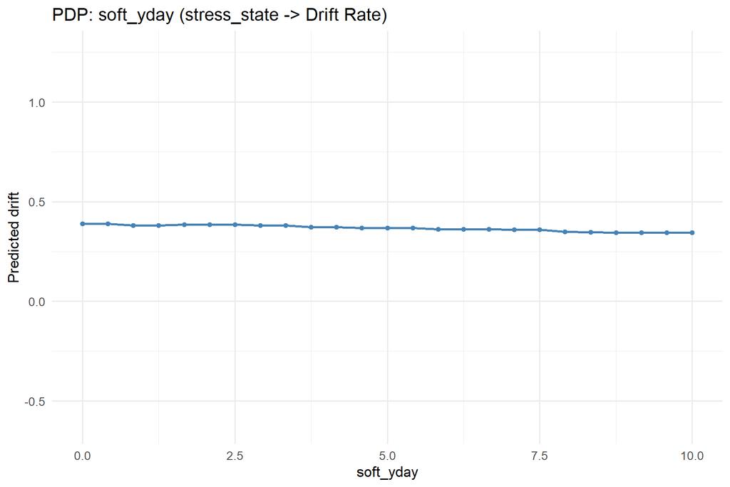

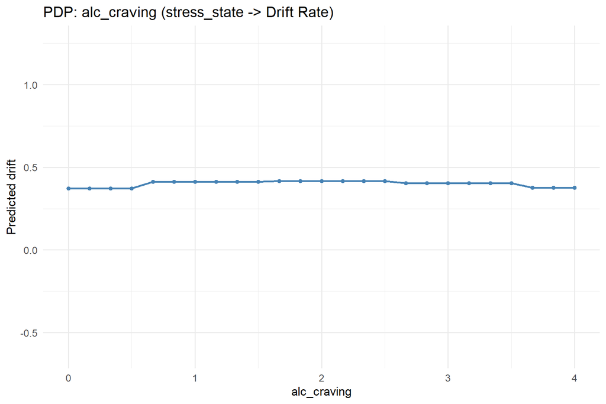

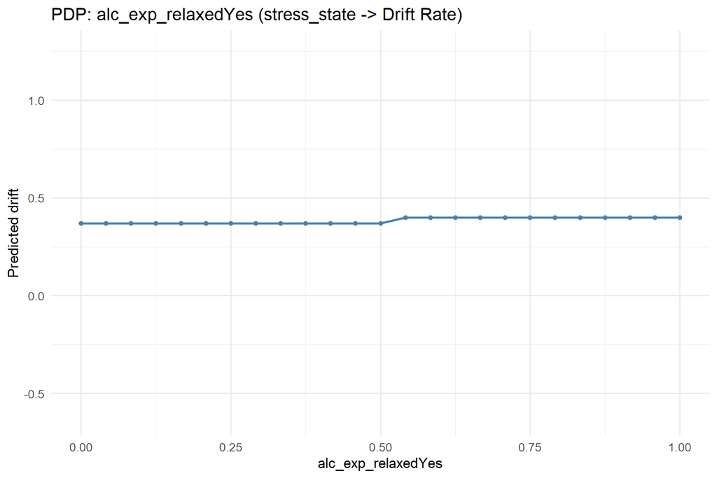

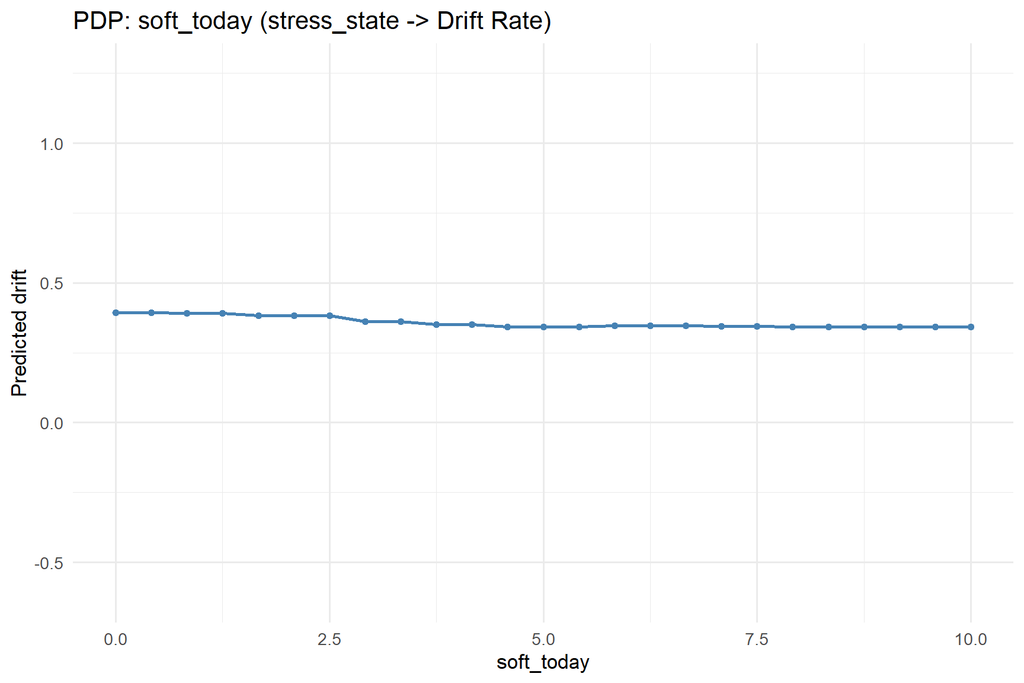

### 3.3.4 Predicted vs. Observed

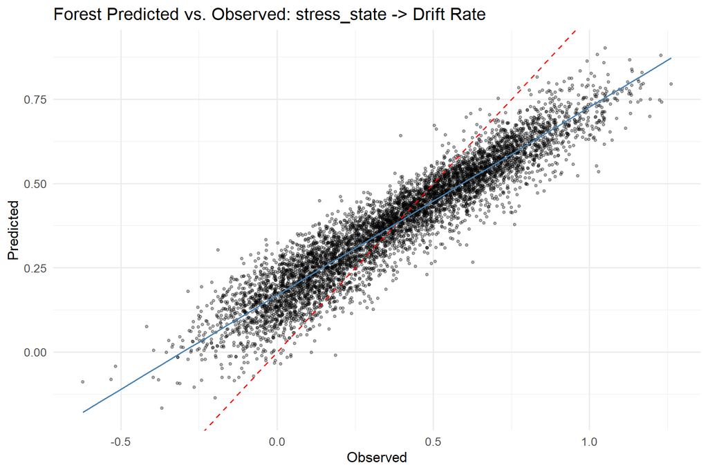

## 3.4 Model Comparison

### 3.4.1 RMSE Comparison (all methods and feature sets)

| Method | Raw | PCA | UMAP |
| --- | --- | --- | --- |
| glmm | 0.3079 | 0.3084 | 0.3050 |
| forest | 0.2560 | 0.2849 | 0.2705 |
| tree | 0.3013 | 0.3011 | 0.3033 |

# 4 Negative Affect State (NA_state)

## 4.1 Dimensionality Reduction

- **PCA components (80% variance, max 5):** 5
- **UMAP components (matching PCA):** 5

### 4.1.1 PCA Component Composition (top 5 correlated variables)

**PC_1**

| Variable | Correlation |
| --- | --- |
| alc_exp_energeticYes | -0.576 |
| alc_exp_better_moodYes | -0.557 |
| alc_exp_sociableYes | -0.547 |
| alc_exp_buzzYes | -0.502 |
| alc_craving | -0.487 |

**PC_2**

| Variable | Correlation |
| --- | --- |
| alc_exp_injuryYes | -0.596 |
| alc_exp_be_rudeYes | -0.594 |
| alc_exp_embarrassedYes | -0.579 |
| alc_exp_nauseous_vomitYes | -0.491 |
| alc_exp_hangoverYes | -0.468 |

**PC_3**

| Variable | Correlation |
| --- | --- |
| locationschool_work | 0.591 |
| alc_today | -0.578 |
| alc_cuenone | 0.569 |
| time_of_dayevening | -0.476 |
| locationhome | -0.457 |

**PC_4**

| Variable | Correlation |
| --- | --- |
| soft_yday | 0.700 |
| soft_today | 0.650 |
| soft_intend | 0.635 |
| soft_craving | 0.488 |
| alc_exp_embarrassedYes | -0.388 |

**PC_5**

| Variable | Correlation |
| --- | --- |
| locationhome | -0.634 |
| social_context_aloneYes | -0.558 |
| social_context_friend_roommateYes | 0.499 |
| social_context_strangerYes | 0.418 |
| locationsomeone_elses_home | 0.371 |

### 4.1.2 UMAP Component Composition (top 5 correlated variables)

**UMAP_1**

| Variable | Correlation |
| --- | --- |
| alc_exp_embarrassedYes | -0.290 |
| alc_exp_be_rudeYes | -0.287 |
| alc_craving | -0.241 |
| alc_intend | -0.230 |
| alc_yday | -0.226 |

**UMAP_2**

| Variable | Correlation |
| --- | --- |
| alc_yday | 0.308 |
| alc_exp_embarrassedYes | -0.201 |
| alc_exp_be_rudeYes | -0.196 |
| alc_intend | 0.116 |
| alc_mot_enhanceYes | 0.113 |

**UMAP_3**

| Variable | Correlation |
| --- | --- |
| alc_yday | 0.470 |
| alc_today | 0.410 |
| alc_cuenone | -0.181 |
| alc_intend | 0.180 |
| alc_exp_be_rudeYes | -0.171 |

**UMAP_4**

| Variable | Correlation |
| --- | --- |
| soft_yday | -0.772 |
| soft_today | -0.669 |
| soft_intend | -0.543 |
| soft_craving | -0.277 |
| alc_exp_be_rudeYes | -0.152 |

**UMAP_5**

| Variable | Correlation |
| --- | --- |
| alc_exp_injuryYes | -0.513 |
| alc_exp_embarrassedYes | -0.378 |
| alc_exp_be_rudeYes | -0.376 |
| alc_exp_nauseous_vomitYes | -0.357 |
| alc_exp_energeticYes | -0.231 |

## 4.2 GLMM Results

### 4.2.1 Raw Features

- **Optimal lambda:** 15 (index 18 of 21)
- **CV RMSE:** 0.3076

**Non-zero coefficients** (focal predictor terms highlighted):

| Term | Estimate | Category |
| --- | --- | --- |
| (Intercept) | 0.3696 | Intercept |
| NA_state | 0.0028 | Focal predictor |
| alc_exp_embarrassedYes | -0.0439 | Covariate main effect |
| alc_exp_injuryYes | -0.0372 | Covariate main effect |
| alc_exp_be_rudeYes | -0.0342 | Covariate main effect |
| alc_exp_hangoverYes | -0.0287 | Covariate main effect |
| alc_exp_nauseous_vomitYes | -0.0255 | Covariate main effect |
| alc_exp_relaxedYes | 0.0231 | Covariate main effect |
| alc_cuenone | -0.0162 | Covariate main effect |
| social_context_strangerYes | 0.0151 | Covariate main effect |
| locationother | 0.0128 | Covariate main effect |
| alc_exp_better_moodYes | 0.0125 | Covariate main effect |
| alc_cueindirectly_visible | -0.0115 | Covariate main effect |
| locationrestaurant_cafe | -0.0100 | Covariate main effect |
| alc_exp_sociableYes | -0.0093 | Covariate main effect |
| social_context_familyYes | -0.0082 | Covariate main effect |
| alc_mot_enhanceYes | 0.0078 | Covariate main effect |
| social_context_coworker_classmateYes | 0.0066 | Covariate main effect |
| responsibilityYes | -0.0066 | Covariate main effect |
| soft_intend | -0.0063 | Covariate main effect |
| alc_mot_copingYes | 0.0058 | Covariate main effect |
| soft_today | -0.0053 | Covariate main effect |
| social_context_romantic_partnerYes | 0.0052 | Covariate main effect |
| alc_intend | 0.0050 | Covariate main effect |
| time_of_dayevening | -0.0049 | Covariate main effect |
| alc_exp_buzzYes | 0.0047 | Covariate main effect |
| bored_state | 0.0040 | Covariate main effect |
| alc_craving | 0.0039 | Covariate main effect |
| soft_yday | -0.0034 | Covariate main effect |
| locationschool_work | -0.0026 | Covariate main effect |

[output cut: 51 more lines]

- 17 coefficients penalized to zero.*

#### 4.2.1.1 Predicted vs. Observed

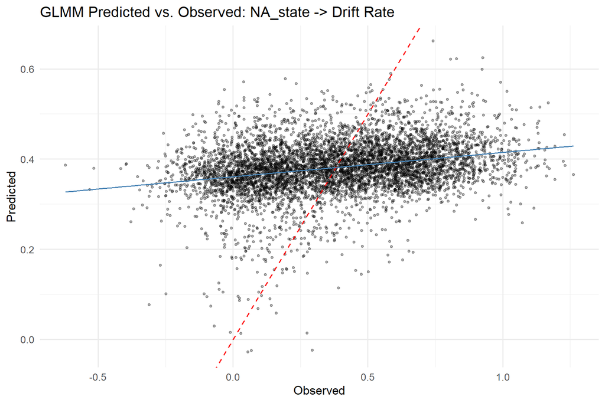

#### 4.2.1.2 Residual Diagnostics

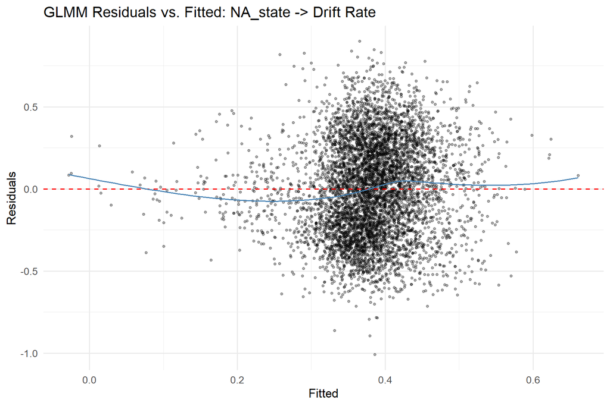

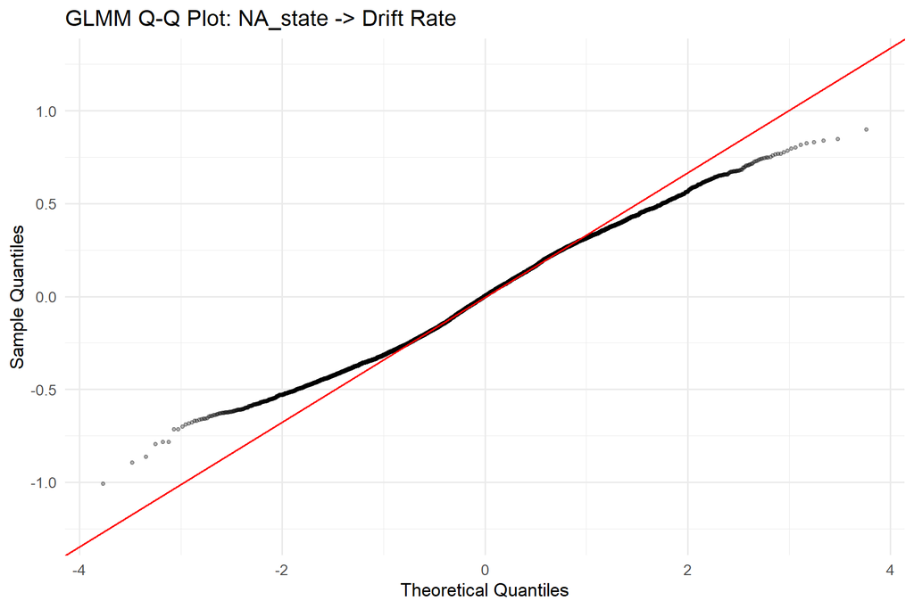

### 4.2.2 PCA Features

- **Optimal lambda:** 95 (index 2 of 21)
- **CV RMSE:** 0.3063

**Non-zero coefficients:**

| Term | Estimate |
| --- | --- |
| (Intercept) | 0.3762 |
| PC_2 | 0.0414 |
| NA_state | 0.0045 |
| PC_2:NA_state | 0.0034 |
| PC_5:NA_state | -0.0087 |

- 7 coefficients penalized to zero.*

### 4.2.3 UMAP Features

- **Optimal lambda:** 100 (index 1 of 21)
- **CV RMSE:** 0.3047

**Non-zero coefficients:**

| Term | Estimate |
| --- | --- |
| (Intercept) | 0.3771 |
| UMAP_3 | 0.0041 |
| UMAP_4 | 0.0140 |
| NA_state | 0.0056 |
| UMAP_3:NA_state | 0.0051 |
| UMAP_4:NA_state | 0.0074 |
| UMAP_5:NA_state | 0.0064 |

- 5 coefficients penalized to zero.*

## 4.3 Random Forest Results (Raw)

### 4.3.1 Tuning Summary

- **mtry:** 21
- **min.node.size:** 4
- **sample.fraction:** 0.69
- **CV RMSE:** 0.2555

### 4.3.2 Variable Importance (Permutation)

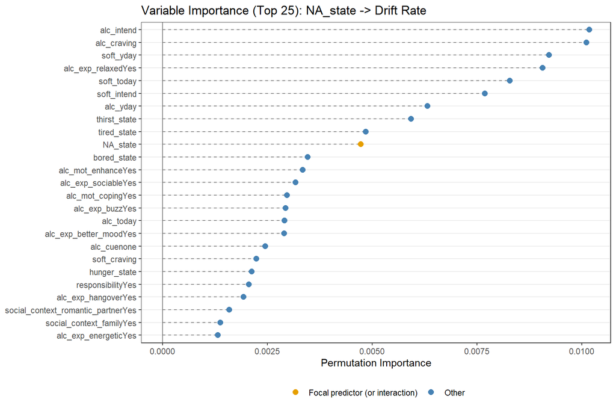

**Full importance ranking:**

| Variable | Importance |
| --- | --- |
| alc_intend | 0.010176 |
| alc_craving | 0.010112 |
| soft_yday | 0.009216 |
| alc_exp_relaxedYes | 0.009059 |
| soft_today | 0.008278 |
| soft_intend | 0.007686 |
| alc_yday | 0.006312 |
| thirst_state | 0.005926 |
| tired_state | 0.004846 |
| NA_state | 0.004726 |
| bored_state | 0.003455 |
| alc_mot_enhanceYes | 0.003340 |
| alc_exp_sociableYes | 0.003174 |
| alc_mot_copingYes | 0.002966 |
| alc_exp_buzzYes | 0.002934 |
| alc_today | 0.002910 |
| alc_exp_better_moodYes | 0.002897 |
| alc_cuenone | 0.002447 |
| soft_craving | 0.002232 |
| hunger_state | 0.002127 |
| responsibilityYes | 0.002055 |
| alc_exp_hangoverYes | 0.001930 |
| social_context_romantic_partnerYes | 0.001591 |
| social_context_familyYes | 0.001377 |
| alc_exp_energeticYes | 0.001313 |
| alc_exp_embarrassedYes | 0.001111 |
| social_context_aloneYes | 0.001005 |
| time_of_dayevening | 0.000810 |
| alc_exp_be_rudeYes | 0.000789 |
| locationhome | 0.000647 |
| alc_mot_socialYes | 0.000505 |
| locationschool_work | 0.000472 |
| alc_exp_nauseous_vomitYes | 0.000363 |
| locationother | 0.000361 |
| alc_exp_injuryYes | 0.000240 |
| alc_cueindirectly_visible | 0.000211 |
| social_context_friend_roommateYes | 0.000206 |
| social_context_coworker_classmateYes | 0.000204 |
| social_context_strangerYes | 0.000163 |
| locationsomeone_elses_home | 0.000074 |
| locationoutdoors | 0.000038 |
| social_context_otherYes | 0.000014 |
| locationrestaurant_cafe | 0.000010 |
| day_of_weekSat | -0.000020 |
| day_of_weekSun | -0.000031 |
| day_of_weekWed | -0.000060 |
| day_of_weekMon | -0.000070 |
| day_of_weekTue | -0.000200 |
| day_of_weekThu | -0.000212 |

### 4.3.3 Partial Dependence Plots

PDP for the focal predictor and the top 5 most important non-interaction covariates.

#### 4.3.3.1 Focal Predictor: NA_state

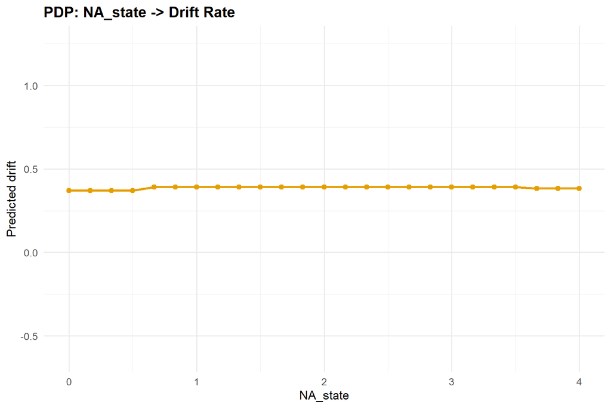

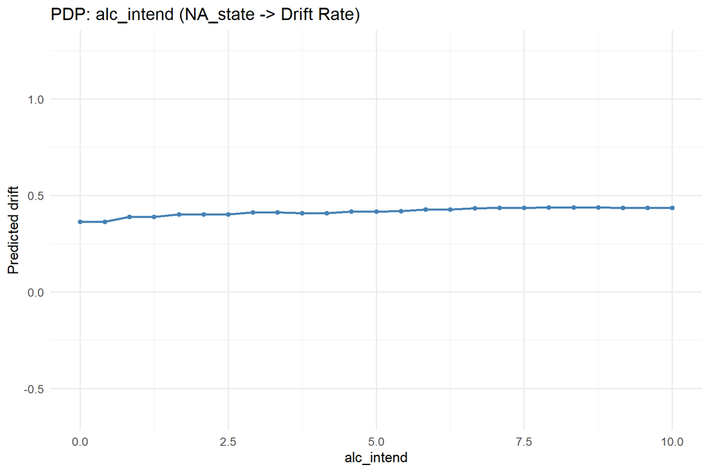

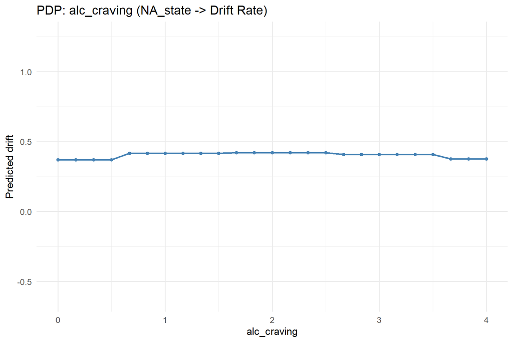

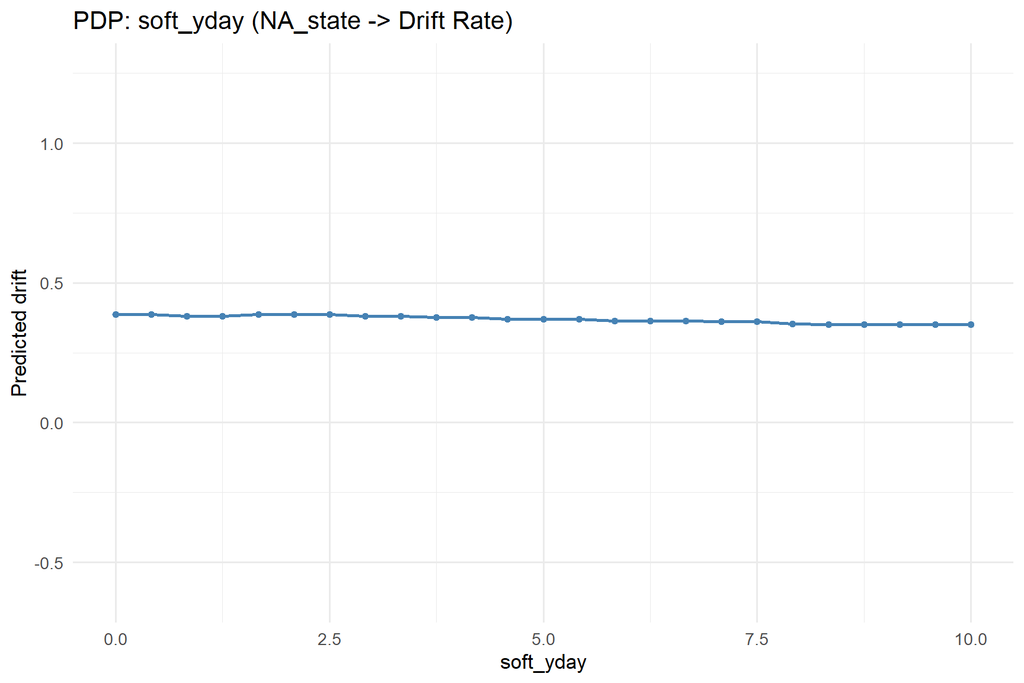

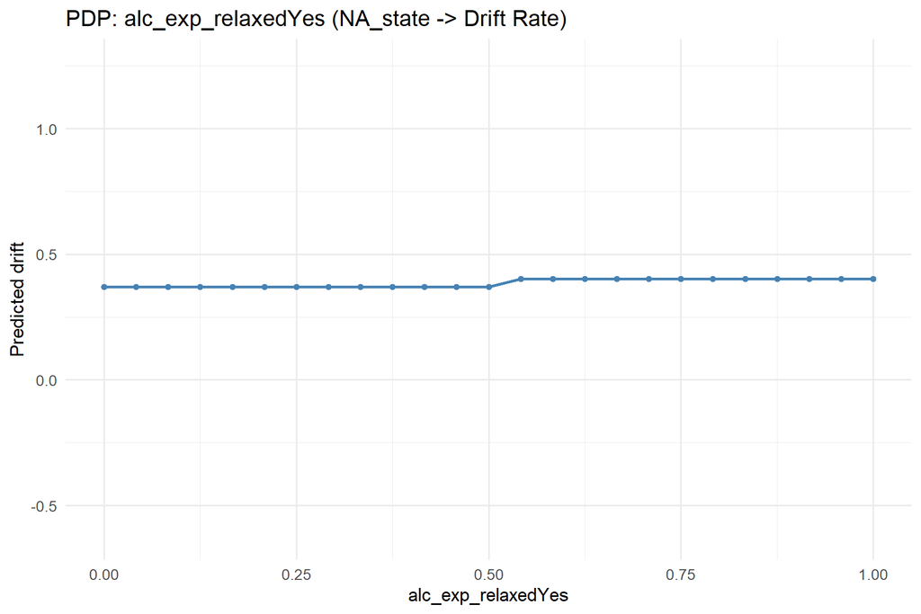

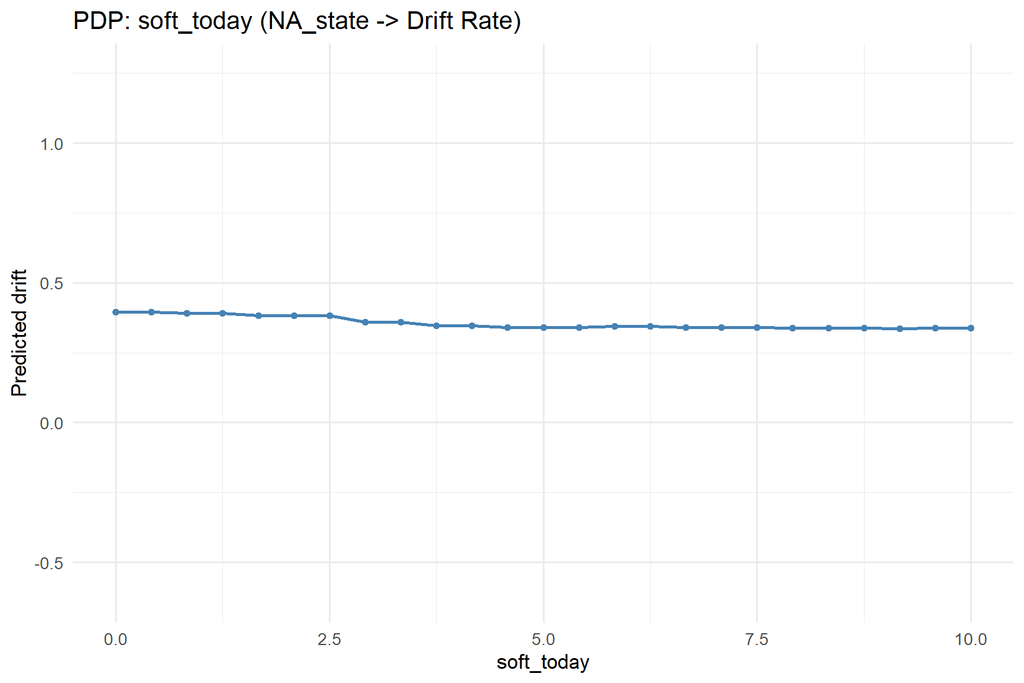